# Parsing data: **HTML files**

HTML is a text-file format that is used widely as the main format for internet sites.

This notebook demonstrates how to parse relatively simple HTML files.

⚠️ **NOTE!** All data files are saved in the same directory as this notebook.

First let's import the modules we'll need for this lecture.

```python
import lxml.html
```

- Simple HTML
- HTML attributes

# HTML

Back to Table of Contents

## `html` Simple HTML

Back to Table of Contents

The file `data4.html` contains the following text:

```
<html lang="en">
    <head>
        <title>Example web page.</title>
    </head>
    <body>
        <p><b>This is an example HTML data file</b></p>
        <p>Mass = 65 kg</p>
        <p>Height = 170 cm</p>
    </body>
</html>
```

This file, when opened in a web browser, looks like this:

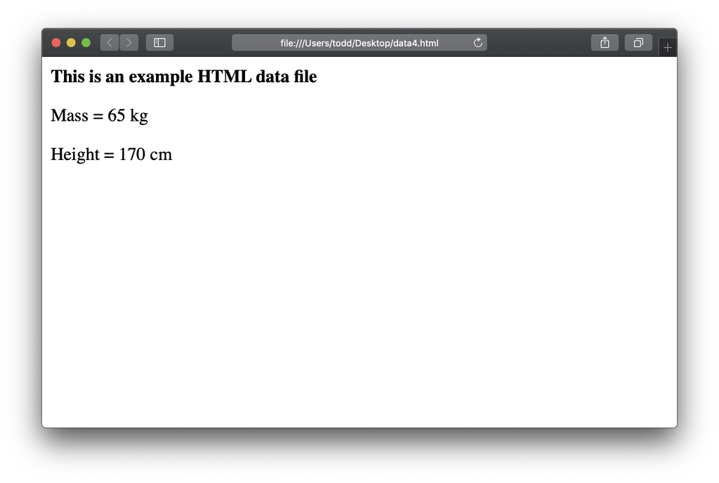

To view the underlying HTML code, open the HTML file in a text editor like Notepad or Wordpad.

Let's use `lxml.html` to parse this HTML file and try to retrieve the mass and height data.

```python
tree      = lxml.html.parse('data4.html')
print(tree)
```

```
<lxml.etree._ElementTree object at 0x7fd9f8372f80>
```

All HTML contents are now saved as an `ElementTree` object in the `tree` variable.

To retrieve a specific node from the element tree, use `find` like this:

```python
head = tree.find('head')
title = head.find('title')

print(title)
```

```
<Element title at 0x7fd9f8443590>
```

To access the text for this element, use the `text` attribute:

```python
s = title.text
print( s )
```

```
Example web page.
```

Alternatively, you can access nested elements like this:

```python
print( tree.find('head').find('title') )
print( tree.find('head/title') )
```

```
<Element title at 0x7fd9f8443590>
<Element title at 0x7fd9f8443590>
```

Thus specific elemets' text can be retrieved using a single command line like this:

```python
s = tree.find('head/title').text
print(s)
```

```
Example web page.
```

Next let's extract all of the text from the body paragraphs (i.e. all `<p>` elements). For this, the `finall` function is convenient.

```python
elements = tree.findall('body/p')

print(elements)
```

```
[<Element p at 0x7fd9f8443bd0>, <Element p at 0x7fd9f8443770>, <Element p at 0x7fd9f8443f90>]
```

Note that three elements are found because there are three paragraphs. The text can be retrieved, similar to above, as follows:

```python
s = [e.text for e in tree.findall('body/p')]

print(s)
```

```
[None, 'Mass = 65 kg', 'Height = 170 cm']
```

Note that no text appears for the first `<p>` element, because there is a `<b>` (bold) element inside the `<p>` element:

```python
print( tree.findall('body/p/b')[0].text )
```

```
This is an example HTML data file
```

For this example, we only want the mass and height data, so we can ignore the first `<p>` element. The second and third elements contain the following text:

```python
s1 = s[1]
s2 = s[2]

print(s1)
print(s2)
```

```
Mass = 65 kg
Height = 170 cm
```

```python
print( s1.split(' ') )
print( s2.split(' ') )
```

```
['Mass', '=', '65', 'kg']
['Height', '=', '170', 'cm']
```

The mass and height are the third items in these lists. We can retrieve them as integers, like this:

```python
mass   = int( s1.split(' ')[2] )
height = int( s2.split(' ')[2] )

print( mass, height )
```

```
65 170
```

Putting everything together, we have:

```python
tree      = lxml.html.parse('data4.html')
elements  = tree.findall('body/p')
mass      = int( elements[1].text.split(' ')[2] )
height    = int( elements[2].text.split(' ')[2] )

print(mass, height)
```

```
65 170
```

## `html` HTML attributes

Back to Table of Contents

Although they cannot be seen in web browsers, they can be very useful for parsing HTML files, as we shall see in the example below.

The file `data5.html` contains the following text:

```
<html>
    <head>
        <title>Example HTML file with attributes</title>
    </head>
    <body>
        <h2>HTML file with attributes</h2>
        <p>
            <button id="X Button">X Button 1</button>
            <span>45</span>
        </p>
        <p>
            <button id="X Button">X Button 2</button>
            <span>90</span>
        </p>
        <p>
            <button id="X Button">X Button 3</button>
            <span>23</span>
        </p>
        <p>
            <button id="Y Button">Y Button 1</button>
            <span>40</span>
        </p>
        <p>
            <button id="Y Button">Y Button 2</button>
            <span>55</span>
        </p>
        <p>
            <button id="X Button">X Button 4</button>
            <span>64</span>
        </p>
    </body>
</html>
```

This file, when opened in a web browser, looks like this:

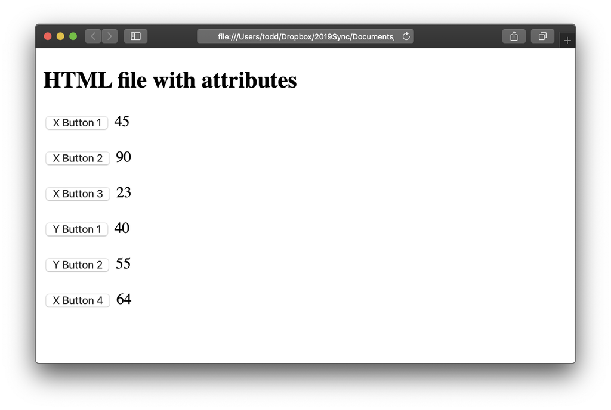

The goal here will be to extract only the "X Button" values. We shall ignore the "Y Button" values.

```python
tree      = lxml.html.parse('data5.html')
elements  = tree.findall('body/p/button')

print(elements)
```

```
[<Element button at 0x7fd9f8456b80>, <Element button at 0x7fd9f8456c20>, <Element button at 0x7fd9f8456c70>, <Element button at 0x7fd9f8456bd0>, <Element button at 0x7fd9f8456b30>, <Element button at 0x7fd9f8456ae0>]
```

All six buttons have been found, but we want only the four "X Button" values. We can check the button type using the `id` attribute:

```python
b = elements[0]
print( b.attrib['id'] )
print( b.attrib['id'] == 'X Button' )
```

```
X Button
True
```

Thus we can retrieve the X buttons by checking the `id` attribute, like this:

```python
elements = [b for b in tree.findall('body/p/button') if b.attrib['id'] == 'X Button']

print( elements )
```

```
[<Element button at 0x7fd9f8456b80>, <Element button at 0x7fd9f8456c20>, <Element button at 0x7fd9f8456c70>, <Element button at 0x7fd9f8456ae0>]
```

Now only the four X button elements are retrieved. Great!

However, we want the values that lie in the `<span>` elements, not in the `<button>` elements, so we need to be a bit more clever in our parsing. Since both the `<button>` and `<span>` elements lie within `<p>` elements, we should parse all `<p>` elements, like this:

```python
data = []
for p in tree.findall('body/p'):
    b = p.find('button')
    if b.attrib['id'] == 'X Button':
        s = p.find('span').text
        data.append( int(s) )

print(data)
```

```
[45, 90, 23, 64]
```